# Risk Factor Analysis

## Outcome Variable

**Outcome Variable:** ever_stunted

## Predictor Variables

**Intervention Variable:** birthlen

**Adjustment Set:**

- arm
- sex
- W_mage
- meducyrs
- feducyrs
- W_mhtcm
- vagbrth
- single
- brthmon
- W_parity
- delta_W_mage
- delta_meducyrs
- delta_feducyrs
- delta_W_mhtcm
- delta_vagbrth
- delta_single
- delta_brthmon
- delta_W_parity

## Stratifying Variables

The analysis was stratified on these variable(s):

- agecat
- studyid
- country

## Data Summary

| agecat | studyid | country | birthlen | ever_stunted | n_cell | n |
| --- | --- | --- | --- | --- | --- | --- |
| 0-6 months | ki0047075b-MAL-ED | BANGLADESH | >=0 | 0 | 39 | 257 |
| 0-6 months | ki0047075b-MAL-ED | BANGLADESH | >=0 | 1 | 0 | 257 |
| 0-6 months | ki0047075b-MAL-ED | BANGLADESH | <-3 | 0 | 0 | 257 |
| 0-6 months | ki0047075b-MAL-ED | BANGLADESH | <-3 | 1 | 9 | 257 |
| 0-6 months | ki0047075b-MAL-ED | BANGLADESH | [-3–2) | 0 | 0 | 257 |
| 0-6 months | ki0047075b-MAL-ED | BANGLADESH | [-3–2) | 1 | 38 | 257 |
| 0-6 months | ki0047075b-MAL-ED | BANGLADESH | [-2–1) | 0 | 83 | 257 |
| 0-6 months | ki0047075b-MAL-ED | BANGLADESH | [-2–1) | 1 | 0 | 257 |
| 0-6 months | ki0047075b-MAL-ED | BANGLADESH | [-1-0) | 0 | 88 | 257 |
| 0-6 months | ki0047075b-MAL-ED | BANGLADESH | [-1-0) | 1 | 0 | 257 |
| 0-6 months | ki0047075b-MAL-ED | BRAZIL | >=0 | 0 | 44 | 191 |
| 0-6 months | ki0047075b-MAL-ED | BRAZIL | >=0 | 1 | 0 | 191 |
| 0-6 months | ki0047075b-MAL-ED | BRAZIL | <-3 | 0 | 0 | 191 |
| 0-6 months | ki0047075b-MAL-ED | BRAZIL | <-3 | 1 | 8 | 191 |
| 0-6 months | ki0047075b-MAL-ED | BRAZIL | [-3–2) | 0 | 0 | 191 |
| 0-6 months | ki0047075b-MAL-ED | BRAZIL | [-3–2) | 1 | 13 | 191 |
| 0-6 months | ki0047075b-MAL-ED | BRAZIL | [-2–1) | 0 | 48 | 191 |
| 0-6 months | ki0047075b-MAL-ED | BRAZIL | [-2–1) | 1 | 0 | 191 |
| 0-6 months | ki0047075b-MAL-ED | BRAZIL | [-1-0) | 0 | 78 | 191 |
| 0-6 months | ki0047075b-MAL-ED | BRAZIL | [-1-0) | 1 | 0 | 191 |
| 0-6 months | ki0047075b-MAL-ED | INDIA | >=0 | 0 | 34 | 206 |
| 0-6 months | ki0047075b-MAL-ED | INDIA | >=0 | 1 | 0 | 206 |
| 0-6 months | ki0047075b-MAL-ED | INDIA | <-3 | 0 | 0 | 206 |
| 0-6 months | ki0047075b-MAL-ED | INDIA | <-3 | 1 | 7 | 206 |
| 0-6 months | ki0047075b-MAL-ED | INDIA | [-3–2) | 0 | 0 | 206 |
| 0-6 months | ki0047075b-MAL-ED | INDIA | [-3–2) | 1 | 26 | 206 |
| 0-6 months | ki0047075b-MAL-ED | INDIA | [-2–1) | 0 | 66 | 206 |
| 0-6 months | ki0047075b-MAL-ED | INDIA | [-2–1) | 1 | 0 | 206 |
| 0-6 months | ki0047075b-MAL-ED | INDIA | [-1-0) | 0 | 73 | 206 |
| 0-6 months | ki0047075b-MAL-ED | INDIA | [-1-0) | 1 | 0 | 206 |

[output cut: 668 more lines]

The following strata were considered:

- agecat: 0-24 months, studyid: ki0047075b-MAL-ED, country: BANGLADESH
- agecat: 0-24 months, studyid: ki0047075b-MAL-ED, country: BRAZIL
- agecat: 0-24 months, studyid: ki0047075b-MAL-ED, country: INDIA
- agecat: 0-24 months, studyid: ki0047075b-MAL-ED, country: NEPAL
- agecat: 0-24 months, studyid: ki0047075b-MAL-ED, country: PERU
- agecat: 0-24 months, studyid: ki0047075b-MAL-ED, country: SOUTH AFRICA
- agecat: 0-24 months, studyid: ki0047075b-MAL-ED, country: TANZANIA, UNITED REPUBLIC OF
- agecat: 0-24 months, studyid: ki1000108-CMC-V-BCS-2002, country: INDIA
- agecat: 0-24 months, studyid: ki1000108-IRC, country: INDIA
- agecat: 0-24 months, studyid: ki1000109-EE, country: PAKISTAN
- agecat: 0-24 months, studyid: ki1000109-ResPak, country: PAKISTAN
- agecat: 0-24 months, studyid: ki1000304b-SAS-CompFeed, country: INDIA
- agecat: 0-24 months, studyid: ki1017093-NIH-Birth, country: BANGLADESH
- agecat: 0-24 months, studyid: ki1017093b-PROVIDE, country: BANGLADESH
- agecat: 0-24 months, studyid: ki1017093c-NIH-Crypto, country: BANGLADESH
- agecat: 0-24 months, studyid: ki1101329-Keneba, country: GAMBIA
- agecat: 0-24 months, studyid: ki1114097-CMIN, country: BANGLADESH
- agecat: 0-24 months, studyid: ki1114097-CMIN, country: BRAZIL
- agecat: 0-24 months, studyid: ki1114097-CMIN, country: PERU
- agecat: 0-24 months, studyid: ki1114097-CONTENT, country: PERU
- agecat: 0-24 months, studyid: ki1119695-PROBIT, country: BELARUS
- agecat: 0-24 months, studyid: ki1126311-ZVITAMBO, country: ZIMBABWE
- agecat: 0-24 months, studyid: ki1135781-COHORTS, country: GUATEMALA
- agecat: 0-24 months, studyid: ki1135781-COHORTS, country: INDIA
- agecat: 0-24 months, studyid: ki1135781-COHORTS, country: PHILIPPINES
- agecat: 0-24 months, studyid: kiGH5241-JiVitA-3, country: BANGLADESH
- agecat: 0-24 months, studyid: kiGH5241-JiVitA-4, country: BANGLADESH
- agecat: 0-6 months, studyid: ki0047075b-MAL-ED, country: BANGLADESH
- agecat: 0-6 months, studyid: ki0047075b-MAL-ED, country: BRAZIL
- agecat: 0-6 months, studyid: ki0047075b-MAL-ED, country: INDIA
- agecat: 0-6 months, studyid: ki0047075b-MAL-ED, country: NEPAL
- agecat: 0-6 months, studyid: ki0047075b-MAL-ED, country: PERU
- agecat: 0-6 months, studyid: ki0047075b-MAL-ED, country: SOUTH AFRICA
- agecat: 0-6 months, studyid: ki0047075b-MAL-ED, country: TANZANIA, UNITED REPUBLIC OF
- agecat: 0-6 months, studyid: ki1000108-CMC-V-BCS-2002, country: INDIA
- agecat: 0-6 months, studyid: ki1000108-IRC, country: INDIA
- agecat: 0-6 months, studyid: ki1000109-EE, country: PAKISTAN
- agecat: 0-6 months, studyid: ki1000109-ResPak, country: PAKISTAN
- agecat: 0-6 months, studyid: ki1000304b-SAS-CompFeed, country: INDIA
- agecat: 0-6 months, studyid: ki1017093-NIH-Birth, country: BANGLADESH
- agecat: 0-6 months, studyid: ki1017093b-PROVIDE, country: BANGLADESH
- agecat: 0-6 months, studyid: ki1017093c-NIH-Crypto, country: BANGLADESH
- agecat: 0-6 months, studyid: ki1101329-Keneba, country: GAMBIA
- agecat: 0-6 months, studyid: ki1114097-CMIN, country: BANGLADESH
- agecat: 0-6 months, studyid: ki1114097-CMIN, country: BRAZIL
- agecat: 0-6 months, studyid: ki1114097-CMIN, country: PERU
- agecat: 0-6 months, studyid: ki1114097-CONTENT, country: PERU
- agecat: 0-6 months, studyid: ki1119695-PROBIT, country: BELARUS
- agecat: 0-6 months, studyid: ki1126311-ZVITAMBO, country: ZIMBABWE
- agecat: 0-6 months, studyid: ki1135781-COHORTS, country: GUATEMALA
- agecat: 0-6 months, studyid: ki1135781-COHORTS, country: INDIA
- agecat: 0-6 months, studyid: ki1135781-COHORTS, country: PHILIPPINES
- agecat: 0-6 months, studyid: kiGH5241-JiVitA-3, country: BANGLADESH
- agecat: 0-6 months, studyid: kiGH5241-JiVitA-4, country: BANGLADESH
- agecat: 6-24 months, studyid: ki0047075b-MAL-ED, country: BANGLADESH
- agecat: 6-24 months, studyid: ki0047075b-MAL-ED, country: BRAZIL
- agecat: 6-24 months, studyid: ki0047075b-MAL-ED, country: INDIA
- agecat: 6-24 months, studyid: ki0047075b-MAL-ED, country: NEPAL
- agecat: 6-24 months, studyid: ki0047075b-MAL-ED, country: PERU
- agecat: 6-24 months, studyid: ki0047075b-MAL-ED, country: SOUTH AFRICA
- agecat: 6-24 months, studyid: ki0047075b-MAL-ED, country: TANZANIA, UNITED REPUBLIC OF
- agecat: 6-24 months, studyid: ki1000108-CMC-V-BCS-2002, country: INDIA
- agecat: 6-24 months, studyid: ki1000108-IRC, country: INDIA
- agecat: 6-24 months, studyid: ki1000109-EE, country: PAKISTAN
- agecat: 6-24 months, studyid: ki1000109-ResPak, country: PAKISTAN
- agecat: 6-24 months, studyid: ki1000304b-SAS-CompFeed, country: INDIA
- agecat: 6-24 months, studyid: ki1017093-NIH-Birth, country: BANGLADESH
- agecat: 6-24 months, studyid: ki1017093b-PROVIDE, country: BANGLADESH
- agecat: 6-24 months, studyid: ki1017093c-NIH-Crypto, country: BANGLADESH
- agecat: 6-24 months, studyid: ki1101329-Keneba, country: GAMBIA
- agecat: 6-24 months, studyid: ki1114097-CMIN, country: BRAZIL
- agecat: 6-24 months, studyid: ki1114097-CMIN, country: PERU
- agecat: 6-24 months, studyid: ki1114097-CONTENT, country: PERU
- agecat: 6-24 months, studyid: ki1119695-PROBIT, country: BELARUS
- agecat: 6-24 months, studyid: ki1126311-ZVITAMBO, country: ZIMBABWE
- agecat: 6-24 months, studyid: ki1135781-COHORTS, country: GUATEMALA
- agecat: 6-24 months, studyid: ki1135781-COHORTS, country: INDIA
- agecat: 6-24 months, studyid: ki1135781-COHORTS, country: PHILIPPINES
- agecat: 6-24 months, studyid: kiGH5241-JiVitA-3, country: BANGLADESH
- agecat: 6-24 months, studyid: kiGH5241-JiVitA-4, country: BANGLADESH


## Methods Detail

We’re interested in the causal parameters $E[Y_a]$ for all values of $a \in \mathcal{A}$. These parameters represent the mean outcome if, possibly contrary to fact, we intervened to set all units to have $A=a$. Under the randomization and positivity assumptions, these are identified by the statistical parameters $\psi_a=E_W[E_{Y|A,W}(Y|A=a,W)]$. In addition, we’re interested in the mean of $Y$, $E[Y]$ under no intervention (the observed mean). We will estimate these parameters by using SuperLearner to fit the relevant likelihood factors – $E_{Y|A,W}(Y|A=a,W)$ and $p(A=a|W)$, and then updating our likelihood fit using a joint TMLE.

For unadjusted analyses ($W=\{\}$), initial likelihoods were estimated using Lrnr_glm to estimate the simple $E(Y|A)$ and Lrnr_mean to estimate $p(A)$. For adjusted analyses, a small library containing Lrnr_glmnet, Lrnr_xgboost, and Lrnr_mean was used.

Having estimated these parameters, we will then use the delta method to estimate relative risks and attributable risks relative to a prespecified baseline level of $A$.

```
##          ever_stunted
## birthlen   0
##   >=0     10
##   <-3      0
##   [-3--2)  0
##   [-2--1)  0
##   [-1-0)   0
```

```
##          ever_stunted
## birthlen     0
##   >=0     1673
##   <-3       56
##   [-3--2)  253
##   [-2--1) 1050
##   [-1-0)  1990
```

# Results Detail

## Results Plots

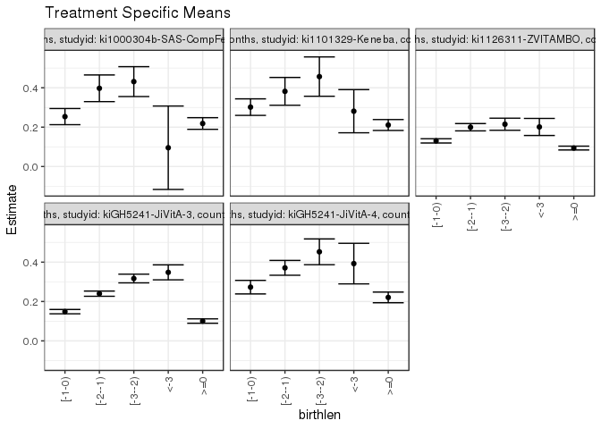

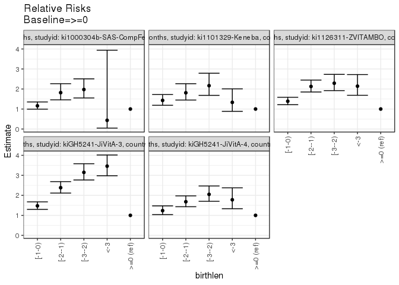

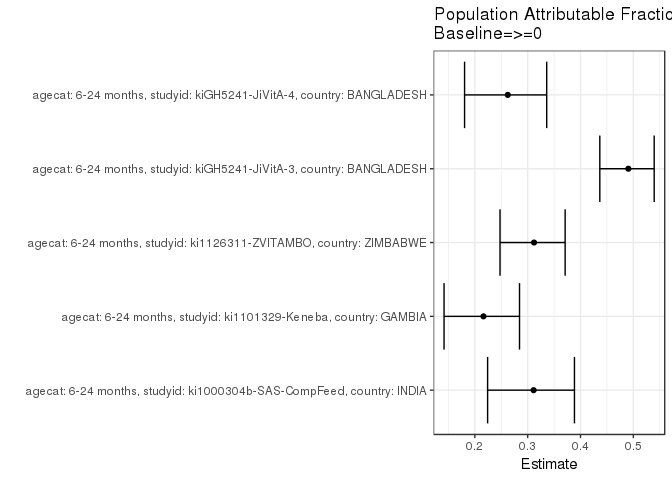

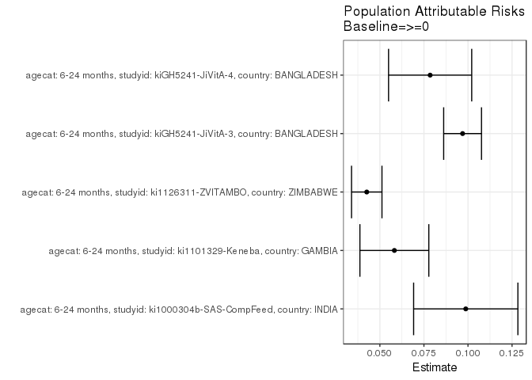

## Results Table

### Parameter: TSM

| agecat | studyid | country | intervention_level | baseline_level | estimate | ci_lower | ci_upper |
| --- | --- | --- | --- | --- | --- | --- | --- |
| 6-24 months | ki1000304b-SAS-CompFeed | INDIA | >=0 | NA | 0.2184901 | 0.1889445 | 0.2480357 |
| 6-24 months | ki1000304b-SAS-CompFeed | INDIA | <-3 | NA | 0.0953644 | -0.1164876 | 0.3072164 |
| 6-24 months | ki1000304b-SAS-CompFeed | INDIA | [-3–2) | NA | 0.4313057 | 0.3554208 | 0.5071905 |
| 6-24 months | ki1000304b-SAS-CompFeed | INDIA | [-2–1) | NA | 0.3973108 | 0.3295506 | 0.4650709 |
| 6-24 months | ki1000304b-SAS-CompFeed | INDIA | [-1-0) | NA | 0.2534713 | 0.2124540 | 0.2944887 |
| 6-24 months | ki1101329-Keneba | GAMBIA | >=0 | NA | 0.2108329 | 0.1830985 | 0.2385673 |
| 6-24 months | ki1101329-Keneba | GAMBIA | <-3 | NA | 0.2809624 | 0.1712668 | 0.3906580 |
| 6-24 months | ki1101329-Keneba | GAMBIA | [-3–2) | NA | 0.4567175 | 0.3568745 | 0.5565605 |
| 6-24 months | ki1101329-Keneba | GAMBIA | [-2–1) | NA | 0.3817776 | 0.3111412 | 0.4524140 |
| 6-24 months | ki1101329-Keneba | GAMBIA | [-1-0) | NA | 0.3017188 | 0.2597230 | 0.3437147 |
| 6-24 months | ki1126311-ZVITAMBO | ZIMBABWE | >=0 | NA | 0.0938102 | 0.0840476 | 0.1035728 |
| 6-24 months | ki1126311-ZVITAMBO | ZIMBABWE | <-3 | NA | 0.2009778 | 0.1576114 | 0.2443442 |
| 6-24 months | ki1126311-ZVITAMBO | ZIMBABWE | [-3–2) | NA | 0.2147667 | 0.1841127 | 0.2454207 |
| 6-24 months | ki1126311-ZVITAMBO | ZIMBABWE | [-2–1) | NA | 0.1995732 | 0.1810417 | 0.2181047 |
| 6-24 months | ki1126311-ZVITAMBO | ZIMBABWE | [-1-0) | NA | 0.1303173 | 0.1194907 | 0.1411439 |
| 6-24 months | kiGH5241-JiVitA-3 | BANGLADESH | >=0 | NA | 0.1006526 | 0.0895570 | 0.1117482 |
| 6-24 months | kiGH5241-JiVitA-3 | BANGLADESH | <-3 | NA | 0.3480929 | 0.3100578 | 0.3861281 |
| 6-24 months | kiGH5241-JiVitA-3 | BANGLADESH | [-3–2) | NA | 0.3167297 | 0.2946888 | 0.3387706 |
| 6-24 months | kiGH5241-JiVitA-3 | BANGLADESH | [-2–1) | NA | 0.2397463 | 0.2265484 | 0.2529442 |
| 6-24 months | kiGH5241-JiVitA-3 | BANGLADESH | [-1-0) | NA | 0.1484617 | 0.1375147 | 0.1594087 |
| 6-24 months | kiGH5241-JiVitA-4 | BANGLADESH | >=0 | NA | 0.2207404 | 0.1936356 | 0.2478451 |
| 6-24 months | kiGH5241-JiVitA-4 | BANGLADESH | <-3 | NA | 0.3924801 | 0.2895103 | 0.4954498 |
| 6-24 months | kiGH5241-JiVitA-4 | BANGLADESH | [-3–2) | NA | 0.4523858 | 0.3869481 | 0.5178235 |
| 6-24 months | kiGH5241-JiVitA-4 | BANGLADESH | [-2–1) | NA | 0.3709024 | 0.3333134 | 0.4084914 |
| 6-24 months | kiGH5241-JiVitA-4 | BANGLADESH | [-1-0) | NA | 0.2728760 | 0.2384432 | 0.3073088 |

### Parameter: E(Y)

| agecat | studyid | country | intervention_level | baseline_level | estimate | ci_lower | ci_upper |
| --- | --- | --- | --- | --- | --- | --- | --- |
| 6-24 months | ki1000304b-SAS-CompFeed | INDIA | NA | NA | 0.3172269 | 0.2868298 | 0.3476240 |
| 6-24 months | ki1101329-Keneba | GAMBIA | NA | NA | 0.2690549 | 0.2450494 | 0.2930603 |
| 6-24 months | ki1126311-ZVITAMBO | ZIMBABWE | NA | NA | 0.1363636 | 0.1293409 | 0.1433864 |
| 6-24 months | kiGH5241-JiVitA-3 | BANGLADESH | NA | NA | 0.1975896 | 0.1895773 | 0.2056019 |
| 6-24 months | kiGH5241-JiVitA-4 | BANGLADESH | NA | NA | 0.2992639 | 0.2810120 | 0.3175157 |

### Parameter: RR

| agecat | studyid | country | intervention_level | baseline_level | estimate | ci_lower | ci_upper |
| --- | --- | --- | --- | --- | --- | --- | --- |
| 6-24 months | ki1000304b-SAS-CompFeed | INDIA | >=0 | >=0 | 1.0000000 | 1.0000000 | 1.000000 |
| 6-24 months | ki1000304b-SAS-CompFeed | INDIA | <-3 | >=0 | 0.4364701 | 0.0483696 | 3.938550 |
| 6-24 months | ki1000304b-SAS-CompFeed | INDIA | [-3–2) | >=0 | 1.9740281 | 1.5539536 | 2.507660 |
| 6-24 months | ki1000304b-SAS-CompFeed | INDIA | [-2–1) | >=0 | 1.8184380 | 1.4592962 | 2.265967 |
| 6-24 months | ki1000304b-SAS-CompFeed | INDIA | [-1-0) | >=0 | 1.1601043 | 0.9943021 | 1.353554 |
| 6-24 months | ki1101329-Keneba | GAMBIA | >=0 | >=0 | 1.0000000 | 1.0000000 | 1.000000 |
| 6-24 months | ki1101329-Keneba | GAMBIA | <-3 | >=0 | 1.3326309 | 0.8840170 | 2.008904 |
| 6-24 months | ki1101329-Keneba | GAMBIA | [-3–2) | >=0 | 2.1662538 | 1.6827628 | 2.788661 |
| 6-24 months | ki1101329-Keneba | GAMBIA | [-2–1) | >=0 | 1.8108070 | 1.4480654 | 2.264416 |
| 6-24 months | ki1101329-Keneba | GAMBIA | [-1-0) | >=0 | 1.4310807 | 1.1878262 | 1.724151 |
| 6-24 months | ki1126311-ZVITAMBO | ZIMBABWE | >=0 | >=0 | 1.0000000 | 1.0000000 | 1.000000 |
| 6-24 months | ki1126311-ZVITAMBO | ZIMBABWE | <-3 | >=0 | 2.1423875 | 1.6863070 | 2.721820 |
| 6-24 months | ki1126311-ZVITAMBO | ZIMBABWE | [-3–2) | >=0 | 2.2893746 | 1.9192483 | 2.730880 |
| 6-24 months | ki1126311-ZVITAMBO | ZIMBABWE | [-2–1) | >=0 | 2.1274143 | 1.8509438 | 2.445181 |
| 6-24 months | ki1126311-ZVITAMBO | ZIMBABWE | [-1-0) | >=0 | 1.3891594 | 1.2164070 | 1.586446 |
| 6-24 months | kiGH5241-JiVitA-3 | BANGLADESH | >=0 | >=0 | 1.0000000 | 1.0000000 | 1.000000 |
| 6-24 months | kiGH5241-JiVitA-3 | BANGLADESH | <-3 | >=0 | 3.4583614 | 2.9789774 | 4.014889 |
| 6-24 months | kiGH5241-JiVitA-3 | BANGLADESH | [-3–2) | >=0 | 3.1467623 | 2.7669931 | 3.578655 |
| 6-24 months | kiGH5241-JiVitA-3 | BANGLADESH | [-2–1) | >=0 | 2.3819194 | 2.1128443 | 2.685262 |
| 6-24 months | kiGH5241-JiVitA-3 | BANGLADESH | [-1-0) | >=0 | 1.4749914 | 1.2996682 | 1.673965 |
| 6-24 months | kiGH5241-JiVitA-4 | BANGLADESH | >=0 | >=0 | 1.0000000 | 1.0000000 | 1.000000 |
| 6-24 months | kiGH5241-JiVitA-4 | BANGLADESH | <-3 | >=0 | 1.7780168 | 1.3312133 | 2.374784 |
| 6-24 months | kiGH5241-JiVitA-4 | BANGLADESH | [-3–2) | >=0 | 2.0494023 | 1.7019727 | 2.467754 |
| 6-24 months | kiGH5241-JiVitA-4 | BANGLADESH | [-2–1) | >=0 | 1.6802656 | 1.4310926 | 1.972823 |
| 6-24 months | kiGH5241-JiVitA-4 | BANGLADESH | [-1-0) | >=0 | 1.2361855 | 1.0367204 | 1.474028 |

### Parameter: PAR

| agecat | studyid | country | intervention_level | baseline_level | estimate | ci_lower | ci_upper |
| --- | --- | --- | --- | --- | --- | --- | --- |
| 6-24 months | ki1000304b-SAS-CompFeed | INDIA | >=0 | NA | 0.0987368 | 0.0691524 | 0.1283211 |
| 6-24 months | ki1101329-Keneba | GAMBIA | >=0 | NA | 0.0582220 | 0.0386712 | 0.0777728 |
| 6-24 months | ki1126311-ZVITAMBO | ZIMBABWE | >=0 | NA | 0.0425534 | 0.0339180 | 0.0511889 |
| 6-24 months | kiGH5241-JiVitA-3 | BANGLADESH | >=0 | NA | 0.0969371 | 0.0862027 | 0.1076714 |
| 6-24 months | kiGH5241-JiVitA-4 | BANGLADESH | >=0 | NA | 0.0785235 | 0.0549300 | 0.1021170 |

### Parameter: PAF

| agecat | studyid | country | intervention_level | baseline_level | estimate | ci_lower | ci_upper |
| --- | --- | --- | --- | --- | --- | --- | --- |
| 6-24 months | ki1000304b-SAS-CompFeed | INDIA | >=0 | NA | 0.3112497 | 0.2241832 | 0.3885450 |
| 6-24 months | ki1101329-Keneba | GAMBIA | >=0 | NA | 0.2163946 | 0.1417242 | 0.2845685 |
| 6-24 months | ki1126311-ZVITAMBO | ZIMBABWE | >=0 | NA | 0.3120585 | 0.2476668 | 0.3709389 |
| 6-24 months | kiGH5241-JiVitA-3 | BANGLADESH | >=0 | NA | 0.4905979 | 0.4365413 | 0.5394685 |
| 6-24 months | kiGH5241-JiVitA-4 | BANGLADESH | >=0 | NA | 0.2623889 | 0.1805930 | 0.3360196 |